# Challenge

```python
# Installa dipendenze
import sys

!{sys.executable} -m pip install numpy==1.18.1 \
                                 pandas==1.0.3 \
                                 matplotlib==3.1.3 \
                                 seaborn==0.10.1 \
                                 scikit-learn==0.22.1 \
                                 Keras==2.3.1 \
                                 tensorflow==2.1.0
```

```python
import numpy as np
import pandas as pd
import matplotlib.pyplot as plt
import seaborn as sns
```

```python
# Load the data
train_data = pd.read_csv('train.csv', parse_dates=['ScheduledDay', 'AppointmentDay'])
test_data = pd.read_csv('test.csv', parse_dates=True)
```

```python
# JUST FOR TESTING NaN Values Behaviour
# train_data.loc[0, 'ScheduledDay'] = np.nan
# train_data.loc[0, 'AppointmentDay'] = np.nan
# train_data.loc[0, 'Neighbourhood'] = np.nan
```

```python
# Mostra il numero di valori univoci e di valori NaN
def stats(df):
    return pd.concat([df.nunique(),
                      df.isnull().sum(),
                      df.dtypes], axis=1).rename({0: 'nunique', 1: 'nancount', 2:'dtype'}, axis=1)
```

```python
stats(train_data)
```

|  | nunique | nancount | dtype |
| --- | --- | --- | --- |
| No-show | 2 | 0 | object |
| PatientId | 46430 | 0 | float64 |
| AppointmentID | 70737 | 0 | int64 |
| Gender | 2 | 0 | object |
| ScheduledDay | 67635 | 0 | datetime64[ns, UTC] |
| AppointmentDay | 27 | 0 | datetime64[ns, UTC] |
| Age | 103 | 0 | int64 |
| Neighbourhood | 81 | 0 | object |
| Scholarship | 2 | 0 | int64 |
| Hipertension | 2 | 0 | int64 |
| Diabetes | 2 | 0 | int64 |
| Alcoholism | 2 | 0 | int64 |
| Handcap | 5 | 0 | int64 |
| SMS_received | 2 | 0 | int64 |

```python
stats(test_data)
```

|  | nunique | nancount | dtype |
| --- | --- | --- | --- |
| No-show | 2 | 0 | object |
| PatientId | 15299 | 0 | float64 |
| AppointmentID | 17684 | 0 | int64 |
| Gender | 2 | 0 | object |
| ScheduledDay | 17432 | 0 | object |
| AppointmentDay | 27 | 0 | object |
| Age | 101 | 0 | int64 |
| Neighbourhood | 79 | 0 | object |
| Scholarship | 2 | 0 | int64 |
| Hipertension | 2 | 0 | int64 |
| Diabetes | 2 | 0 | int64 |
| Alcoholism | 2 | 0 | int64 |
| Handcap | 5 | 0 | int64 |
| SMS_received | 2 | 0 | int64 |

```python
test_data.describe()
```

|  | PatientId | AppointmentID | Age | Scholarship | Hipertension | Diabetes | Alcoholism | Handcap | SMS_received |
| --- | --- | --- | --- | --- | --- | --- | --- | --- | --- |
| count | 1.768400e+04 | 1.768400e+04 | 17684.000000 | 17684.000000 | 17684.000000 | 17684.000000 | 17684.000000 | 17684.000000 | 17684.000000 |
| mean | 1.471165e+14 | 5.675934e+06 | 37.294108 | 0.097885 | 0.197976 | 0.068989 | 0.029744 | 0.022676 | 0.321194 |
| std | 2.560258e+14 | 7.145723e+04 | 23.189484 | 0.297168 | 0.398485 | 0.253442 | 0.169886 | 0.169144 | 0.466948 |
| min | 5.628261e+06 | 5.122866e+06 | 0.000000 | 0.000000 | 0.000000 | 0.000000 | 0.000000 | 0.000000 | 0.000000 |
| 25% | 3.944518e+12 | 5.641065e+06 | 18.000000 | 0.000000 | 0.000000 | 0.000000 | 0.000000 | 0.000000 | 0.000000 |
| 50% | 3.187615e+13 | 5.681512e+06 | 37.000000 | 0.000000 | 0.000000 | 0.000000 | 0.000000 | 0.000000 | 0.000000 |
| 75% | 9.451584e+13 | 5.726215e+06 | 56.000000 | 0.000000 | 0.000000 | 0.000000 | 0.000000 | 0.000000 | 1.000000 |
| max | 9.999320e+14 | 5.790464e+06 | 115.000000 | 1.000000 | 1.000000 | 1.000000 | 1.000000 | 4.000000 | 1.000000 |

```python
# Full overview
train_data
```

|  | No-show | PatientId | AppointmentID | Gender | ScheduledDay | AppointmentDay | Age | Neighbourhood | Scholarship | Hipertension | Diabetes | Alcoholism | Handcap | SMS_received |
| --- | --- | --- | --- | --- | --- | --- | --- | --- | --- | --- | --- | --- | --- | --- |
| 0 | No | 4.952644e+12 | 5623073 | F | 2016-04-26 13:30:37+00:00 | 2016-06-02 00:00:00+00:00 | 37 | MARIA ORTIZ | 0 | 0 | 0 | 0 | 0 | 1 |
| 1 | No | 4.554548e+12 | 5706309 | M | 2016-05-17 08:07:58+00:00 | 2016-06-08 00:00:00+00:00 | 7 | GURIGICA | 0 | 0 | 0 | 0 | 0 | 1 |
| 2 | Yes | 4.947944e+14 | 5683575 | F | 2016-05-11 07:39:04+00:00 | 2016-05-13 00:00:00+00:00 | 54 | CARATOÍRA | 0 | 1 | 0 | 0 | 0 | 0 |
| 3 | Yes | 6.173362e+10 | 5601630 | M | 2016-04-19 13:23:27+00:00 | 2016-05-11 00:00:00+00:00 | 30 | ITARARÉ | 0 | 0 | 0 | 0 | 0 | 1 |
| 4 | Yes | 4.685218e+13 | 5637343 | M | 2016-04-28 18:54:43+00:00 | 2016-05-05 00:00:00+00:00 | 36 | DA PENHA | 0 | 0 | 0 | 0 | 0 | 1 |
| ... | ... | ... | ... | ... | ... | ... | ... | ... | ... | ... | ... | ... | ... | ... |
| 70732 | No | 2.274979e+11 | 5637742 | M | 2016-04-29 07:20:46+00:00 | 2016-04-29 00:00:00+00:00 | 36 | RESISTÊNCIA | 0 | 0 | 0 | 0 | 0 | 0 |
| 70733 | No | 7.121343e+11 | 5703714 | M | 2016-05-16 14:19:14+00:00 | 2016-05-17 00:00:00+00:00 | 75 | JARDIM CAMBURI | 0 | 0 | 0 | 0 | 0 | 0 |
| 70734 | Yes | 6.548658e+13 | 5419687 | F | 2016-03-02 09:23:07+00:00 | 2016-05-03 00:00:00+00:00 | 39 | JESUS DE NAZARETH | 0 | 0 | 0 | 0 | 0 | 1 |
| 70735 | No | 8.321622e+13 | 5668575 | F | 2016-05-06 09:21:16+00:00 | 2016-05-13 00:00:00+00:00 | 61 | JARDIM DA PENHA | 0 | 0 | 0 | 0 | 0 | 0 |
| 70736 | No | 7.278595e+14 | 5669717 | M | 2016-05-06 11:28:33+00:00 | 2016-05-09 00:00:00+00:00 | 71 | JARDIM CAMBURI | 0 | 0 | 0 | 0 | 0 | 0 |

70737 rows × 14 columns

```python
print('Numero di righe totali: ', train_data.shape[0], '\n')
for col in train_data.columns:
    print('Colonna: {}, classi totali: {}, tipo di dato: {}'.format(col,
                                                                    len(train_data[col].unique()),
                                                                    train_data[col].dtype))
    print(train_data[col].unique(), '\n')
```

```
Numero di righe totali:  70737

Colonna: No-show, classi totali: 2, tipo di dato: object
['No' 'Yes']

Colonna: PatientId, classi totali: 46430, tipo di dato: float64
[4.95264356e+12 4.55454769e+12 4.94794366e+14 ... 7.12134333e+11
 6.54865825e+13 7.27859544e+14]

Colonna: AppointmentID, classi totali: 70737, tipo di dato: int64
[5623073 5706309 5683575 ... 5419687 5668575 5669717]

Colonna: Gender, classi totali: 2, tipo di dato: object
['F' 'M']

Colonna: ScheduledDay, classi totali: 67635, tipo di dato: datetime64[ns, UTC]
<DatetimeArray>
['2016-04-26 13:30:37+00:00', '2016-05-17 08:07:58+00:00',
 '2016-05-11 07:39:04+00:00', '2016-04-19 13:23:27+00:00',
 '2016-04-28 18:54:43+00:00', '2016-04-26 09:10:53+00:00',
 '2016-05-09 07:25:04+00:00', '2016-05-03 10:17:05+00:00',
 '2016-05-19 13:48:17+00:00', '2016-05-05 09:18:46+00:00',
 ...
 '2016-04-25 10:35:58+00:00', '2016-04-06 08:02:35+00:00',
 '2016-05-18 13:11:57+00:00', '2016-05-06 09:38:36+00:00',
 '2016-05-19 17:24:39+00:00', '2016-04-20 08:18:03+00:00',
 '2016-04-05 15:56:01+00:00', '2016-04-29 07:20:46+00:00',
 '2016-03-02 09:23:07+00:00', '2016-05-06 11:28:33+00:00']
Length: 67635, dtype: datetime64[ns, UTC]

Colonna: AppointmentDay, classi totali: 27, tipo di dato: datetime64[ns, UTC]
<DatetimeArray>
['2016-06-02 00:00:00+00:00', '2016-06-08 00:00:00+00:00',
 '2016-05-13 00:00:00+00:00', '2016-05-11 00:00:00+00:00',
 '2016-05-05 00:00:00+00:00', '2016-04-29 00:00:00+00:00',
 '2016-05-09 00:00:00+00:00', '2016-05-24 00:00:00+00:00',
 '2016-05-20 00:00:00+00:00', '2016-05-03 00:00:00+00:00',
 '2016-05-17 00:00:00+00:00', '2016-05-19 00:00:00+00:00',
 '2016-05-10 00:00:00+00:00', '2016-05-06 00:00:00+00:00',
 '2016-06-03 00:00:00+00:00', '2016-05-30 00:00:00+00:00',
```

[output cut: 38 more lines]

```

Colonna: Hipertension, classi totali: 2, tipo di dato: int64
[0 1]

Colonna: Diabetes, classi totali: 2, tipo di dato: int64
[0 1]

Colonna: Alcoholism, classi totali: 2, tipo di dato: int64
[0 1]

Colonna: Handcap, classi totali: 5, tipo di dato: int64
[0 1 3 2 4]

Colonna: SMS_received, classi totali: 2, tipo di dato: int64
[1 0]
```

### Appunti:

- PatientId non ha cardinalità uguale a quella del dataset, lo stesso paziente può prendere più appuntamenti. Forse si potrebbe usare come feature perché potrebbero esserci pazienti più inclini a non rispettare appuntamenti di altri a prescindere dalle altre features.
- AppointmentID è univoco, si può scartare.
- Entrambe le date andrebbero mantenute, eventualmente con qualche trasformazione. AppointmentDay ha solo 27 valori univoci.
- Age, credo sia da usare ma prima ci sono da indagare eventuali correlazioni...
- Neighbourhood potrebbe determinare il risultato se alcuni posti sono "fuori mano" ma sono 81 classi!... da rivedere.
- Le restanti sono features categoriche che, nel momento in cui scrivo, terrei tutte.

```python
# Provo a generare una feature a partire dalle date, dopo raffinerò il processo.

# Copia di sicurezza
train_copy = train_data.copy()

# Aggiunge la colonna dei giorni di distanza tra la richiesta e l'appuntamento
# Nota: in caso di date NaN anche WaitingDay sarà NaN, questo si gestirà nel preprocessore.
train_copy['WaitingDays'] = (train_data.AppointmentDay.dt.date - train_data.ScheduledDay.dt.date).dt.days
```

## Analisi features numeriche

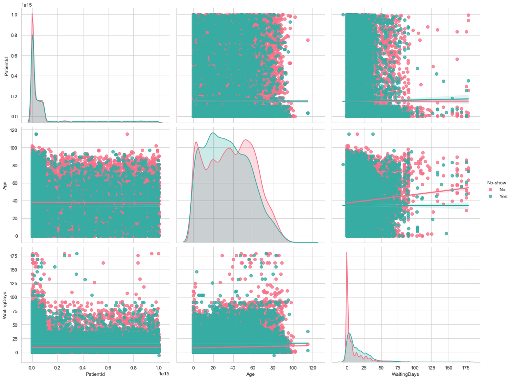

```python
sns.set_style('whitegrid')

nfplot = sns.pairplot(train_copy[['PatientId', 'Age', 'WaitingDays', 'No-show']],
                      hue="No-show",
                      kind='reg',
                      dropna=True,
                      palette='husl',
                      height=3.5,
                      aspect=1.3)

plt.show(nfplot)
```

Per quanto riguarda le features numeriche:

- **PatientId** non sembra essere correlato al target.
- **Age** mostra una leggera correlazione al target (almeno per quanto riguarda la distribuzione).
- **WaitingDays** ha qualche correlazione al target ed ai giorni di attesa.

## Analisi Features categoriche

#### (Quelli in rosso NON si sono presentati all'appuntamento)

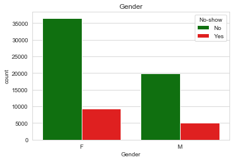

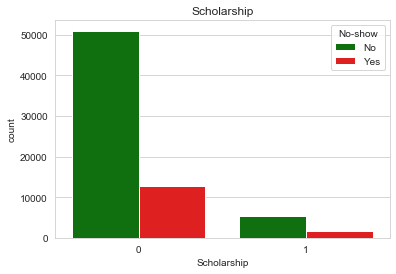

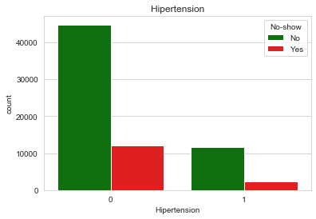

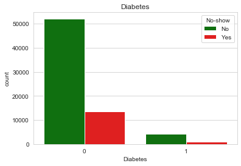

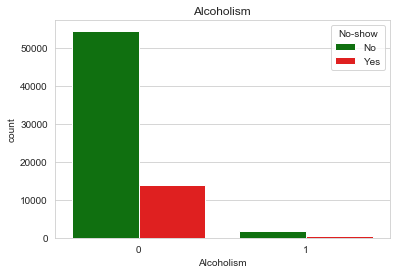

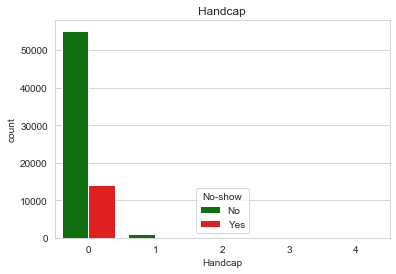

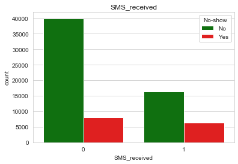

```python
# Features categoriche
cat_features = ['Gender', 'Scholarship', 'Hipertension', 'Diabetes', 'Alcoholism', 'Handcap', 'SMS_received']

for f in cat_features:
    catplot = sns.countplot(x=f, hue='No-show', data=train_copy, palette=sns.color_palette(['Green', 'Red']))
    plt.title(f)
    plt.show(catplot)
```

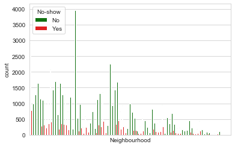

```python
# Un caso a parte: Neighbourhood
genplot = sns.countplot(x='Neighbourhood', hue='No-show', data=train_copy, palette=sns.color_palette(['Green', 'Red']))
plt.xticks([])
plt.show(genplot)
```

```python
# Statistiche su percentuale di presenti per luogo
nbh_stats = train_copy.groupby(['Neighbourhood', 'No-show']).size() # Tabella d'appoggio temporanea
nbh_stats = nbh_stats.unstack() # Converte in indice semplice con due colonne Yes e No
nbh_stats['Total'] = nbh_stats.No + nbh_stats.Yes # Aggiunge una colonna con il totale
nbh_stats['ShowFrac'] = nbh_stats.No / nbh_stats.Total # Calcola la frazione di chi si è presentato all'appuntamento
nbh_stats
```

| No-show Neighbourhood | No | Yes | Total | ShowFrac |
| --- | --- | --- | --- | --- |
| AEROPORTO | 4.0 | 1.0 | 5.0 | 0.800000 |
| ANDORINHAS | 1105.0 | 321.0 | 1426.0 | 0.774895 |
| ANTÔNIO HONÓRIO | 131.0 | 30.0 | 161.0 | 0.813665 |
| ARIOVALDO FAVALESSA | 139.0 | 45.0 | 184.0 | 0.755435 |
| BARRO VERMELHO | 209.0 | 55.0 | 264.0 | 0.791667 |
| ... | ... | ... | ... | ... |
| SÃO JOSÉ | 985.0 | 278.0 | 1263.0 | 0.779889 |
| SÃO PEDRO | 1276.0 | 346.0 | 1622.0 | 0.786683 |
| TABUAZEIRO | 1648.0 | 366.0 | 2014.0 | 0.818272 |
| UNIVERSITÁRIO | 75.0 | 23.0 | 98.0 | 0.765306 |
| VILA RUBIM | 455.0 | 90.0 | 545.0 | 0.834862 |

81 rows × 4 columns

```python
# Mostra in quale range di valori varia il rapporto presentati/totali per ciascun luogo
print('Frazione minima: ', nbh_stats['ShowFrac'].min(), ' Frazione massima: ', nbh_stats['ShowFrac'].max())
```

```
Frazione minima:  0.6  Frazione massima:  0.9583333333333334
```

##### Nella maggior parte dei casi la percentuale di chi si presenta all'appuntamento è sempre abbastanza maggiore rispetto a chi non si presenta, potrebbe esserci qualche correlazione tra luogo dell'appuntamento e target ma per ora questa feature non sarà considerata.

## Preparazione dati

```python
# Classificatore età
def age_class(age):

    if np.isnan(age):
        return np.nan
    elif age < 10:
        return '<10'
    elif age < 20:
        return '10-19'
    elif age < 30:
        return '20-29'
    elif age < 40:
        return '30-39'
    elif age < 50:
        return '40-49'
    elif age < 60:
        return '50-59'
    elif age < 70:
        return '60-69'
    else:
        return '70+'

# Test
age_class(34)
```

```
'30-39'
```

```python
# Classificatore giorni di attesa
def wdays_class(wdays):

    if np.isnan(wdays):
        return np.nan
    elif wdays == 0:
        return 'today'
    elif wdays < 7:
        return 'days'
    elif wdays < 30:
        return 'weeks'
    elif wdays < 90:
        return 'months'
    else:
        return 'long'

# Test
wdays_class(np.nan)
```

```
nan
```

```python
# Features selection e features engineering
# Prende un DataFrame e restituisce un DataFrame pronto per il preprocessing
def refine(df):

    # Copia il dataframe solo per sicurezza
    x = df.copy()

    # Aggiunge la colonna dei giorni di distanza tra la richiesta e l'appuntamento
    # Nota: in caso di date NaN anche WaitingDay sarà NaN, questo si gestirà nel preprocessore.
    x['WaitingDays'] = (train_data.AppointmentDay.dt.date - train_data.ScheduledDay.dt.date).dt.days

    # Categorizza età
    x['Age'] = x.Age.apply(age_class)

    # Categorizza i giorni di attesa
    x['WaitingDays'] = x.WaitingDays.apply(wdays_class)

    # Feature selection
    x.drop(['AppointmentID', 'PatientId', 'ScheduledDay', 'AppointmentDay'], axis=1, inplace=True)

    return x
```

```python
# Test
refine(train_data.drop(['No-show'], axis=1))
```

|  | Gender | Age | Neighbourhood | Scholarship | Hipertension | Diabetes | Alcoholism | Handcap | SMS_received | WaitingDays |
| --- | --- | --- | --- | --- | --- | --- | --- | --- | --- | --- |
| 0 | F | 30-39 | MARIA ORTIZ | 0 | 0 | 0 | 0 | 0 | 1 | months |
| 1 | M | <10 | GURIGICA | 0 | 0 | 0 | 0 | 0 | 1 | weeks |
| 2 | F | 50-59 | CARATOÍRA | 0 | 1 | 0 | 0 | 0 | 0 | days |
| 3 | M | 30-39 | ITARARÉ | 0 | 0 | 0 | 0 | 0 | 1 | weeks |
| 4 | M | 30-39 | DA PENHA | 0 | 0 | 0 | 0 | 0 | 1 | weeks |
| ... | ... | ... | ... | ... | ... | ... | ... | ... | ... | ... |
| 70732 | M | 30-39 | RESISTÊNCIA | 0 | 0 | 0 | 0 | 0 | 0 | today |
| 70733 | M | 70+ | JARDIM CAMBURI | 0 | 0 | 0 | 0 | 0 | 0 | days |
| 70734 | F | 30-39 | JESUS DE NAZARETH | 0 | 0 | 0 | 0 | 0 | 1 | months |
| 70735 | F | 60-69 | JARDIM DA PENHA | 0 | 0 | 0 | 0 | 0 | 0 | weeks |
| 70736 | M | 70+ | JARDIM CAMBURI | 0 | 0 | 0 | 0 | 0 | 0 | days |

70737 rows × 10 columns

## Preprocessore

```python
from sklearn.preprocessing import OneHotEncoder, OrdinalEncoder, LabelBinarizer
from sklearn.preprocessing import Normalizer, MinMaxScaler, PowerTransformer, StandardScaler, RobustScaler
from sklearn.impute import SimpleImputer
from sklearn.compose import ColumnTransformer
from sklearn.pipeline import Pipeline
```

```python
# Codifica predittori

ohenc = Pipeline(steps=[ ('imputer', SimpleImputer(strategy='most_frequent')),
                         ('ohenc', OneHotEncoder(handle_unknown='ignore', sparse=False)) ])

orenc = Pipeline(steps=[ ('imputer', SimpleImputer(strategy='most_frequent')),
                         ('ohenc', OrdinalEncoder()) ])

colt = ColumnTransformer(transformers=[('ohenc', ohenc, ['Gender', 'Age', 'WaitingDays', 'Handcap']),
                                       ('orenc', orenc, ['Neighbourhood']) ], remainder='passthrough')


preprocessor = Pipeline(steps=[ ('s1', colt),
                                ('imputer', SimpleImputer(strategy='most_frequent')),
                                ('scaler', Normalizer(norm='l1'))
                              ])
```

```python
# Test
p = preprocessor.fit_transform(refine(train_data.drop(['No-show'], axis=1)))
pd.DataFrame(p)
```

|  | 0 | 1 | 2 | 3 | 4 | 5 | 6 | 7 | 8 | 9 | ... | 16 | 17 | 18 | 19 | 20 | 21 | 22 | 23 | 24 | 25 |
| --- | --- | --- | --- | --- | --- | --- | --- | --- | --- | --- | --- | --- | --- | --- | --- | --- | --- | --- | --- | --- | --- |
| 0 | 0.020833 | 0.000000 | 0.0 | 0.0 | 0.020833 | 0.0 | 0.000000 | 0.000000 | 0.00000 | 0.00000 | ... | 0.0 | 0.0 | 0.0 | 0.0 | 0.895833 | 0.0 | 0.000000 | 0.0 | 0.0 | 0.020833 |
| 1 | 0.000000 | 0.031250 | 0.0 | 0.0 | 0.000000 | 0.0 | 0.000000 | 0.000000 | 0.00000 | 0.03125 | ... | 0.0 | 0.0 | 0.0 | 0.0 | 0.843750 | 0.0 | 0.000000 | 0.0 | 0.0 | 0.031250 |
| 2 | 0.071429 | 0.000000 | 0.0 | 0.0 | 0.000000 | 0.0 | 0.071429 | 0.000000 | 0.00000 | 0.00000 | ... | 0.0 | 0.0 | 0.0 | 0.0 | 0.642857 | 0.0 | 0.071429 | 0.0 | 0.0 | 0.000000 |
| 3 | 0.000000 | 0.024390 | 0.0 | 0.0 | 0.024390 | 0.0 | 0.000000 | 0.000000 | 0.00000 | 0.00000 | ... | 0.0 | 0.0 | 0.0 | 0.0 | 0.878049 | 0.0 | 0.000000 | 0.0 | 0.0 | 0.024390 |
| 4 | 0.000000 | 0.050000 | 0.0 | 0.0 | 0.050000 | 0.0 | 0.000000 | 0.000000 | 0.00000 | 0.00000 | ... | 0.0 | 0.0 | 0.0 | 0.0 | 0.750000 | 0.0 | 0.000000 | 0.0 | 0.0 | 0.050000 |
| ... | ... | ... | ... | ... | ... | ... | ... | ... | ... | ... | ... | ... | ... | ... | ... | ... | ... | ... | ... | ... | ... |
| 70732 | 0.000000 | 0.015873 | 0.0 | 0.0 | 0.015873 | 0.0 | 0.000000 | 0.000000 | 0.00000 | 0.00000 | ... | 0.0 | 0.0 | 0.0 | 0.0 | 0.936508 | 0.0 | 0.000000 | 0.0 | 0.0 | 0.000000 |
| 70733 | 0.000000 | 0.023810 | 0.0 | 0.0 | 0.000000 | 0.0 | 0.000000 | 0.000000 | 0.02381 | 0.00000 | ... | 0.0 | 0.0 | 0.0 | 0.0 | 0.904762 | 0.0 | 0.000000 | 0.0 | 0.0 | 0.000000 |
| 70734 | 0.022222 | 0.000000 | 0.0 | 0.0 | 0.022222 | 0.0 | 0.000000 | 0.000000 | 0.00000 | 0.00000 | ... | 0.0 | 0.0 | 0.0 | 0.0 | 0.888889 | 0.0 | 0.000000 | 0.0 | 0.0 | 0.022222 |
| 70735 | 0.023256 | 0.000000 | 0.0 | 0.0 | 0.000000 | 0.0 | 0.000000 | 0.023256 | 0.00000 | 0.00000 | ... | 0.0 | 0.0 | 0.0 | 0.0 | 0.906977 | 0.0 | 0.000000 | 0.0 | 0.0 | 0.000000 |
| 70736 | 0.000000 | 0.023810 | 0.0 | 0.0 | 0.000000 | 0.0 | 0.000000 | 0.000000 | 0.02381 | 0.00000 | ... | 0.0 | 0.0 | 0.0 | 0.0 | 0.904762 | 0.0 | 0.000000 | 0.0 | 0.0 | 0.000000 |

70737 rows × 26 columns

```python
# Codifica target
lbenc = LabelBinarizer()
```

```python
# Test
lbenc.fit_transform(train_data['No-show'])
```

```
array([[0],
       [0],
       [1],
       ...,
       [1],
       [0],
       [0]])
```

## Modello

```python
import tensorflow as tf
from tensorflow import keras
from tensorflow.keras import layers
from keras.wrappers.scikit_learn import KerasClassifier
```

```python
def model_builder(input_size, layer_sizes):

    inputs = keras.Input(shape=(input_size,))
    x = layers.Dense(layer_sizes[0], activation="relu")(inputs)

    # Aggiungi layers
    for size in layer_sizes[1:]:
        x = layers.Dense(size, activation="relu")(x)
        x = layers.Dropout(0.3)(x)

    outputs = layers.Dense(1, activation='sigmoid')(x)

    model = keras.Model(inputs=inputs, outputs=outputs, name="model")

    model.compile(loss='mse', optimizer='adam', metrics=["accuracy"])

    return model

# Test
model_builder(10, [11, 12]).summary()
```

```
Model: "model"
_________________________________________________________________
Layer (type)                 Output Shape              Param #
=================================================================
input_1 (InputLayer)         [(None, 10)]              0
_________________________________________________________________
dense (Dense)                (None, 11)                121
_________________________________________________________________
dense_1 (Dense)              (None, 12)                144
_________________________________________________________________
dropout (Dropout)            (None, 12)                0
_________________________________________________________________
dense_2 (Dense)              (None, 1)                 13
=================================================================
Total params: 278
Trainable params: 278
Non-trainable params: 0
_________________________________________________________________
```

```python
# Model Wrapping for Sklearn
model = KerasClassifier(model_builder)
```

## Addestramento

```python
# Separa target da predittori
X_train = train_data.drop(['No-show'], axis=1)
y_train = train_data['No-show']
```

```python
# Preprocessa i dati
X_train_matrix = preprocessor.fit_transform(refine(X_train))
y_train_matrix = lbenc.fit_transform(y_train)
```

```python
# K-fold crossvalidation
from sklearn.model_selection import cross_val_score


CVDIM = 5 # Numero di blocchi usati per validation

model.set_params(input_size=X_train_matrix.shape[1],
                            layer_sizes=(32, 32, 32),
                            epochs=2,
                            batch_size=16,
                            verbose=1)

# titanic_model_wrapper.set_params(validation_split=0)
print('Cross validation su {} samples, validation set size: {}'.format(X_train_matrix.shape[0],
                                                                       X_train_matrix.shape[0]//CVDIM))

scores = cross_val_score(model, X_train_matrix, y_train_matrix, cv=CVDIM, scoring='accuracy')

print('\n', scores, ' Mean: ', scores.mean())
```

```
Cross validation su 70737 samples, validation set size: 14147
Train on 56589 samples
Train on 56589 samples
Train on 56590 samples
Train on 56590 samples
Train on 56590 samples

 [0.79339836 0.79170201 0.79465611 0.8009472  0.80172475]  Mean:  0.7964856845922451
```

```python
# Imposta il modello
model = model.set_params(input_size=X_train_matrix.shape[1],
                         layer_sizes=(32, 32, 32),
                         epochs=25,
                         batch_size=16,
                         verbose=1,
                         validation_split=0.2)
```

```python
# Addestramento
history = model.fit(X_train_matrix, y_train_matrix)
```

```
Train on 56589 samples, validate on 14148 samples
```

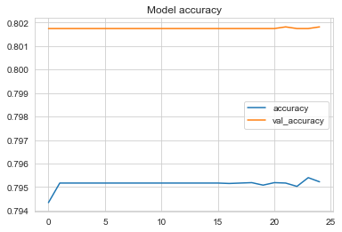

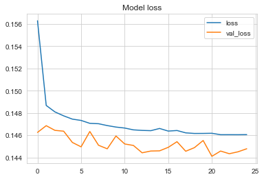

```python
# Visualizza risultati addestramento
history_data = pd.DataFrame(history.history)

sns.lineplot(data=history_data[['accuracy', 'val_accuracy']], dashes=False)
plt.title('Model accuracy')
plt.show()

sns.lineplot(data=history_data[['loss', 'val_loss']], dashes=False)
plt.title('Model loss')
plt.show()
```

```python
# Testa il modello sui "nuovi" dati
X_test = test_data.drop(['No-show'], axis=1)
y_test = test_data['No-show']

X_test_matrix = preprocessor.transform(refine(X_test))
y_test_matrix = lbenc.transform(y_test)

test_scores = model.score(X_test_matrix, y_test_matrix)
```

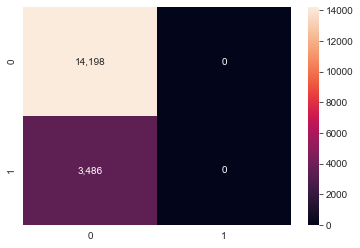

```python
# Confusion matrix
from sklearn.metrics import confusion_matrix
from sklearn.metrics import ConfusionMatrixDisplay

# Utilizzo il modello per predire tutto il test set
pred = model.predict(X_test_matrix).round()

# Calculate Confusion Matrix
cm = confusion_matrix(y_test_matrix, pred)
hm = sns.heatmap(cm, annot=True, fmt=',.0f')
plt.show(hm)

# 1 == No-show, 0 == show
```

**Considerazioni:** Il grafico del training è strano, ho ottenuto un comportamento simile con la challenge del Titanic ma in quel caso sono riuscito a mitigare l'effetto val_accuracy >> train_accuracy aumentando la percentuale di validation set. In **questo** caso non si schioda dallo 0.80, può succedere perché i dati hanno un forte bias o perché il validation set è troppo "semplice" ma non mi sembra il caso...

#### Ci sono troppe persone che si sono presentate e poche che non si sono presentate.

## Bilanciamento del dataset

Negli addestramenti precedenti si ottiene l'80% fisso, tuttavia questo succede perché la maggior parte dei pazienti si presenta all'appuntamento e come si vede dalla heat map questo falsa i risultati. In questa parte, addestro lo stesso modello bilanciando il dataset in modo tale che ci siano numeri equivalenti di label.

```python
# Bilancia i dati in modo che ci siano tante label di una classe quante dell'altra
def balance(df):
    num_noshow = df[train_data['No-show'] == 'Yes'].shape[0]
    num_show = df.shape[0] - num_noshow

    if num_noshow > num_show:
        data_show = df.loc[df['No-show'] == 'No']
        data_noshow = df.loc[df['No-show'] == 'Yes'].sample(n=num_show)
    else:
        data_noshow = df.loc[df['No-show'] == 'Yes']
        data_show = df.loc[df['No-show'] == 'No'].sample(n=num_noshow)

    return pd.concat([data_show, data_noshow],
                     axis=0,
                     ignore_index=True).sample(frac=1, random_state=42).reset_index(drop=True)
```

```python
# Il dataset bilanciato
bal_train_data = balance(train_data)
```

```python
# Divisione predittori e target
bal_X = bal_train_data.drop(['No-show'], axis=1)
bal_y = bal_train_data['No-show']
```

```python
# Matrici di input ottenute con lo stesso preprocessore
bal_X_train_matrix = preprocessor.transform(refine(bal_X))
bal_y_train_matrix = lbenc.transform(bal_y)
```

```python
# Imposta parametri del modello
model = model.set_params(input_size=bal_X_train_matrix.shape[1],
                         layer_sizes=(32, 32, 32),
                         epochs=25,
                         batch_size=16,
                         verbose=1,
                         validation_split=0.2)
```

```python
# Addestramento
bal_history = model.fit(bal_X_train_matrix, bal_y_train_matrix)
```

```
Train on 23033 samples, validate on 5759 samples
```

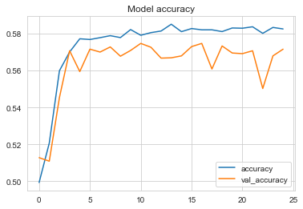

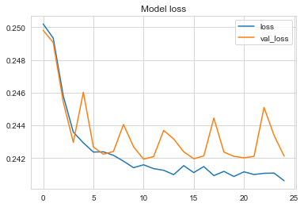

```python
# Visualizza risultati addestramento
bal_history_data = pd.DataFrame(bal_history.history)

sns.lineplot(data=bal_history_data[['accuracy', 'val_accuracy']], dashes=False)
plt.title('Model accuracy')
plt.show()

sns.lineplot(data=bal_history_data[['loss', 'val_loss']], dashes=False)
plt.title('Model loss')
plt.show()
```

```python
# Testa il modello sui "nuovi" dati (non è necessario bilanciarli)
bal_test_scores = model.score(X_test_matrix, y_test_matrix)
```

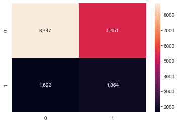

```python
# Confusion matrix

# Utilizzo il modello per predire tutto il test set
bal_pred = model.predict(X_test_matrix).round()

# Calcola Confusion Matrix
bal_cm = confusion_matrix(y_test_matrix, bal_pred)
bal_hm = sns.heatmap(bal_cm, annot=True, fmt=',.0f')
plt.show(bal_hm)

# 1 == No-show, 0 == show
```